# Clinical Graphics

Author

Maxime Fleury

**📌 About Us**

**Links**

Personal website (comming soon)

**contact:** fleurym@ipc.unicancer.fr

**License**

Clinical Graphics by Maxime FLEURY is licensed under CC BY-NC-SA 4.0

[figure not shown]

**Community**

[Innostatclinical](https://innostatclinical.com/en/)

**Contributor**

Maxime Fleury, *Author, maintainer* - Health Statistician

**Dev status**

*Vignette creation:* 11/12/2025

*Last update:* 11/12/2025

*Repos status:* Active

# Overview

The **rise of innovative therapies**—particularly in oncology, such as **immunotherapy**—combined with the rapid development of **artificial intelligence**, has increased the **complexity of clinical questions and hypotheses**. In this evolving scientific landscape, it is essential to develop **new data visualization** approaches capable of representing more **multidimensional and dynamic phenomena**. These visual strategies complement and strengthen traditional methods, enhancing both analytical **precision and the clarity** of presented results.

We distinguish two main categories of graphics:

**Analysis Graphics**

These graphics aim to **enhance the understanding of results**. They allow rapid visualization of population profiles across treatment groups and categorical variables (e.g., sex, HER2 status), help detect statistical differences, and highlight key findings relevant to the clinical trial.

**Objectives:**

- **Facilitate dialogue** among stakeholders involved in the trial
- Provide an **intuitive, fast, and impactful** reading experience
- Serve as a **support for scientific** presentations (articles, conferences, slide decks, posters)

**Patient profile graphics**

These graphics are designed to facilitate and accelerate clinical decision-making.

**Objectives:**

- **Visualization** and better **understanding** of the database structure
- Assessment of **data quality** for statistical analysis
- Improved **clinical statistical follow-up** of each patient by highlighting individual and global trends.Through these representations, deriving survival endpoints and longitudinal indicators becomes easier

**Integration in DSMB**: During Data Safety Monitoring Board (DSMB) meetings, these graphics serve as a strategic tool: they enable rapid **detection of inconsistencies**, support timely and **effective decision-making**, and provide critical elements to **ensure patient safety** throughout the study.

These graphics must comply with clinical research standards and are strongly encouraged by international guidelines such as **CDISC, ICH, EMA, and FDA**.

## Objectives

The purpose of this work is to **present a set of essential graphical representations** that support the execution of high-quality clinical trials. All examples are derived from datasets structured according to **CDISC** (Clinical Data Interchange Standards Consortium) standards in **ADaM** (Analysis Data Model) format, ensuring compliance with regulatory and industry requirements. The visualizations are **implemented using R, Python3, and SAS** to demonstrate versatility and adherence to best practices in clinical data analysis.

Data has been generated with [*random.cdisc*](https://insightsengineering.github.io/random.cdisc.data/main/index.html) library of the CRAN in R (Version 4.2.0). Specifically, data used are :

- **adsl:** Subject-Level Analysis Dataset (ADSL)
- **adae:** Adverse Event Analysis Dataset (ADAE)
- **adrs:** Response Analysis Dataset (ADRS)
- **adlb:** Laboratory Data Analysis Dataset (ADLB)
- **adtte:** Time-to-Event Dataset (ADTTE)
- **adex:** Exposure Analysis Dataset (ADEX)

# Graphics

## Analysis

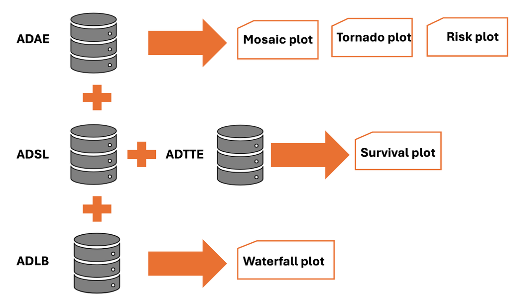

## Patient profil

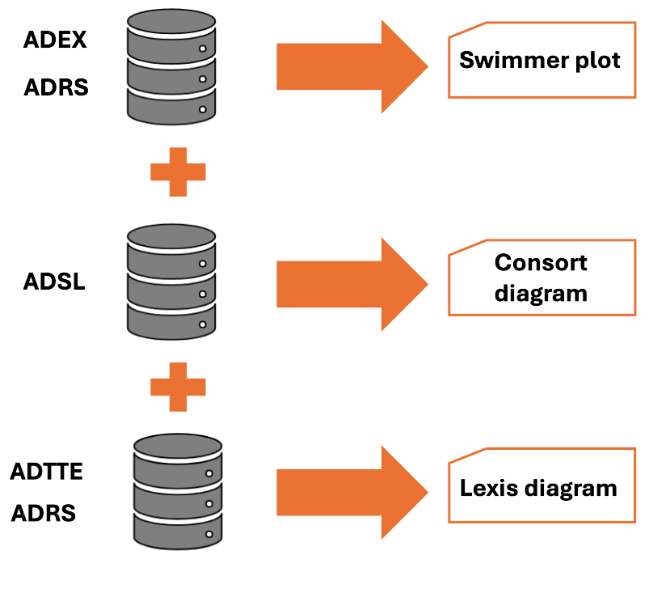

# References

- [CDISC ADaM](https://www.cdisc.org/standards/foundational/adam)
- [ADaM Data Structure for Adverse Event Analysis v1.0](https://www.cdisc.org/standards/foundational/adam/adam-data-structure-adverse-event-analysis-v1-0)
- Rucki P, Paszty N, Stoilova J, Zhu J, Garolini D, de la Rua E, DiPietrantonio C, Waddell A (2025). *random.cdisc.data: Create Random ADaM Datasets*. R package version 0.3.16.9007,